# Chapter 13 – Convolutional Neural Networks

CNN은 이미지 인식에 주로 사용된다. 주로 이미지 검색 서비스, 자율주행 자동차, 자동 비디오 분류 시스템을 지원한다.

음성인식이나 자연어처리(NLP; natural language processing)와 같은 업무에서도 사용된다.

Chapter 13은 텐서플로를 사용하여 CNN을 구현하는 방법에 대해 설명하고 그 구조를 살펴본다.

## 1. The Architecture of the Visual Cortex

- 시각 피질의 많은 뉴런들이 small local receptive field를 가지고 시각적 자극에만 반응한다는 것을 알아냈다.
- 각 뉴런의 receptive field는 겹칠수 있으며 수평선 이미지에만 반응하는 뉴런과 방향이 다른것에만 반응하는 뉴런을 발견했다.
- 일부 뉴런은 더 큰 receptive field를 가지고 낮은 수준의 패턴의 조합인 복잡한 패턴에 더 잘 반응한다
- 이러한 사실을 통해 높은 수준의 뉴런이 인접한 낮은 수준의 뉴런 출력을 기반으로 한다는 것을 알아냈다.
- 이 구조는 모든 시각적 영역의 복잡한 패턴을 감지할 수 있다.

[figure not shown]

이러한 사실을 통해 지금의 convoluutional neural network 가 발전했고 1998년 'LeNet-5' 구조가 소개되었다.  
이 구조는 sigmoid 활성화 함수, fully connected layers 와 함께 **convolutional layer, pooling layer** 등이 추가 된 형태이다.

## 2. Convolutional Layer

- CNN에서 가장 중요한 Building Block은 Convolutional layer이다.
- 첫번째 Convolutional layer는 Input 이미지의 모든 픽셀과 연결되지 않고 첫번째 layer의 receptive field의 pixel만 연결된다.
- 두번째 Convolutional layer의 각 뉴런은 첫번째 레이어의 작은 사각형 안의 뉴런에만 연결된다.
- 이 계층적 구조는 CNN이 이미지 인식을 위해 잘 작동하는 이유 중 하나이다.

[figure not shown]

- 주어진 레이어의 i행, j열에 위치한 뉴련은 이전 레이어의 $i$에서 $i+f_h -1$과 $j$에서 $j+f_w-1$에 위치한 뉴런의 출력에 연결된다.
- 여기서 $f_h$와 $f_w$는 receptive fields의 높이와 너비이다.
- 레이어가 이전 레이어와 동일한 너비와 높이를 가지려면 입력레이어 주위에 0을 추가하는 것이 일반적이다. : **'Zero Padding'**

[figure not shown]

- 아래 그림처럼 receptive fields의 간격을 두어 큰 입력 레이어를 더 작은레이어에 연결할 수도 있다.
- 두 개의 연속적인 receptive fields 사이의 거리 : **stride**
- 그림에서 3x3의 receptive field와 stride 2를 사용하여 5x7의 입력레이어(zero padding 추가)가 3x4 레이어에 연결된다.
- stride는 양방향이 꼭 동일할 필요는 없다
- 상위 레이어의 i행, j열에 위치한 뉴런은 하위레이어의 $i\times s_h$에서 $i\times s_h+f_h-1$행과 $j\times s_w$에서 $j\times s_w+f_w-1$의 열의 출력에 연결된다.
- 이때, $s_h$와$s_w$ 는 수직, 수평의 stride에 해당한다.

[figure not shown]

### 2.1 Filters

[figure not shown]

- 그림은 filter 또는 convolutional kernel 이라 하는 두 가지의 가중치 셋을 나타낸다.
- 첫번째는 수직선, 두번째는 수평선을 제외하고 receptive fields의 모든 것을 무시한다.
- 동일한 필터를 사용하는 뉴런으로 가득 찬 레이어는 필터와 유사한 이미지 영역을 강조하여 표시하는 feature map을 제공한다.

### 2.2 stacking Multiple Feature Maps

- 실제로 convolutional layer는 크기가 동일한 몇 개의 feature map으로 구성되어 3차원으로 표현된다.

[figure not shown]

- 하나의 feature map에서 모든 뉴런은 동일한 파라미터(가중치 및 bias)를 공유하지만 다른 feature map은 다른 파라미터를 가질 수 있다.
- 다시말해 컨볼루션 레이어는 입력에 여러 필터를 동시에 적용하여 입력의 여러 feature들을 감지할 수 있다.
- 또한 입력 이미지는 여러개의 하위 레이어로 구성되는데 일반적으로 빨강, 녹색, 파랑(RGB) 3가지가 있다.
- 구체적인 식으로 컨볼루션 레이어에서 주어진 뉴런의 출력을 계산하는 방법은 다음과 같다.

[figure not shown]

- $z_i,j,k$는 컨볼루션 레이어의 feature map k에서 행 i, 열 j 에 위치한 뉴련의 output이다.
- $f_n$은 이전레이어의 feature map의 개수
- $b_k$는 레이어 l에서 feature map k에 대한 bias term이다.

# Setup

First, let's make sure this notebook works well in both python 2 and 3, import a few common modules, ensure MatplotLib plots figures inline and prepare a function to save the figures:

```python
# To support both python 2 and python 3
from __future__ import division, print_function, unicode_literals

# Common imports
import numpy as np
import os

# to make this notebook's output stable across runs
def reset_graph(seed=42):
    tf.reset_default_graph()
    tf.set_random_seed(seed)
    np.random.seed(seed)

# To plot pretty figures
%matplotlib inline
import matplotlib
import matplotlib.pyplot as plt
plt.rcParams['axes.labelsize'] = 14
plt.rcParams['xtick.labelsize'] = 12
plt.rcParams['ytick.labelsize'] = 12

# Where to save the figures
PROJECT_ROOT_DIR = "."
CHAPTER_ID = "cnn"

def save_fig(fig_id, tight_layout=True):
    path = os.path.join(PROJECT_ROOT_DIR, "images", CHAPTER_ID, fig_id + ".png")
    print("Saving figure", fig_id)
    if tight_layout:
        plt.tight_layout()
    plt.savefig(path, format='png', dpi=300)
```

A couple utility functions to plot grayscale and RGB images:

```python
def plot_image(image):
    plt.imshow(image, cmap="gray", interpolation="nearest")
    plt.axis("off")

def plot_color_image(image):
    plt.imshow(image.astype(np.uint8),interpolation="nearest")
    plt.axis("off")
```

And of course we will need TensorFlow:

```python
import tensorflow as tf
```

# Convolutional layer

```python
from sklearn.datasets import load_sample_image  # load_sample_image로 두개의 샘플 이미지를 로드한다.
china = load_sample_image("china.jpg")     # 하나는 중국 사원
flower = load_sample_image("flower.jpg")   # 하나는 꽃
image = china[150:220, 130:250]
height, width, channels = image.shape
image_grayscale = image.mean(axis=2).astype(np.float32)
images = image_grayscale.reshape(1, height, width, 1)
```

[output not shown]

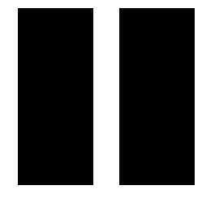

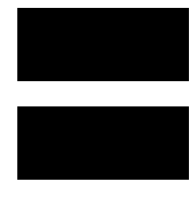

```python
fmap = np.zeros(shape=(7, 7, 1, 2), dtype=np.float32)
fmap[:, 3, 0, 0] = 1
fmap[3, :, 0, 1] = 1
plot_image(fmap[:, :, 0, 0])
plt.show()
plot_image(fmap[:, :, 0, 1])
plt.show()
```

```python
reset_graph()

X = tf.placeholder(tf.float32, shape=(None, height, width, 1))
feature_maps = tf.constant(fmap)
convolution = tf.nn.conv2d(X, feature_maps, strides=[1,1,1,1], padding="SAME")
```

```python
with tf.Session() as sess:
    output = convolution.eval(feed_dict={X: images})
```

```
Saving figure china_original
```

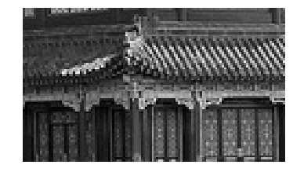

```python
plot_image(images[0, :, :, 0])
save_fig("china_original", tight_layout=False)
plt.show()
```

```
Saving figure china_vertical
```

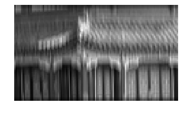

```python
plot_image(output[0, :, :, 0])
save_fig("china_vertical", tight_layout=False)
plt.show()
```

```
Saving figure china_horizontal
```

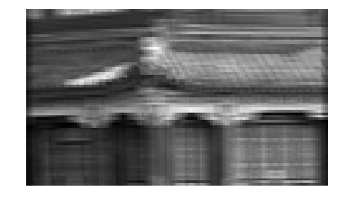

```python
plot_image(output[0, :, :, 1])
save_fig("china_horizontal", tight_layout=False)
plt.show()
```

## Simple example

### 2.3 TensorFlow Implementation

- 텐서플로에서 각 입력이미지는 일반적으로 3차원 텐서 shape[height, weight, channels]로 표현된다
- mini-batch는 4차원 텐서 shape[mini-batch size, height, width, channels]로 표현된다.
- 컨볼루션 레이어의 weight는 4차원 텐서 shape[f_h, f_w, f_n', f_n]이다.
- 컨볼루션 레이어의 bias는 1차원 텐서 shape [f_n]이다.
- 두개의 7x7 필터를 만든다 (하나는 세로 흰색선, 하나는 가로 흰색선)
- 텐서플로의 tf.nn.conv2d()를 통해 컨볼루션 레이어를 사용하여 두 이미지에 적용한다.
- feature map 중 하나를 plot한다

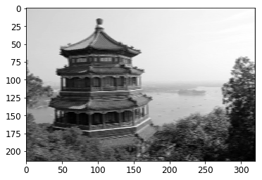

```python
import numpy as np
from sklearn.datasets import load_sample_images

# Load sample images
china = load_sample_image("china.jpg")
flower = load_sample_image("flower.jpg")
dataset = np.array([china, flower], dtype=np.float32)
batch_size, height, width, channels = dataset.shape

# Create 2 filters
filters = np.zeros(shape=(7, 7, channels, 2), dtype=np.float32)
filters[:, 3, :, 0] = 1  # vertical line
filters[3, :, :, 1] = 1  # horizontal line

# Create a graph with input X plus a convolutional layer applying the 2 filters
X = tf.placeholder(tf.float32, shape=(None, height, width, channels))
convolution = tf.nn.conv2d(X, filters, strides=[1,2,2,1], padding="SAME")

with tf.Session() as sess:
    output = sess.run(convolution, feed_dict={X: dataset})

plt.imshow(output[0, :, :, 1], cmap="gray") # plot 1st image's 2nd feature map
plt.show()
```

- `tf.nn.conv2d`의 X는 입력 mini-batch(4차원)
- filter는 적용할 필터의 집합
- stride는 4개의 요소의 1차원 배열, 중간의 두 개의 요소는 vertical / horizontal strides ($s_h, s_w$)
- stride의 첫번째와 마지막 요소는 1로 해야하고 이 값은 batch stride 와 channel stride를 지정하는데 사용할 수 있다.
- padding은 valid와 same 중 하나를 선택한다.
- valid : stride에 따라 입력이미지의 하단과 오른쪽 일부 행과 열을 무시할 수 있다.
- same : zero padding을 사용한다. output 뉴런의 개수는 input 뉴런의 수를 올림으로 나눈 값과 같다

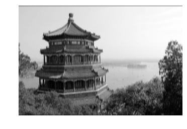

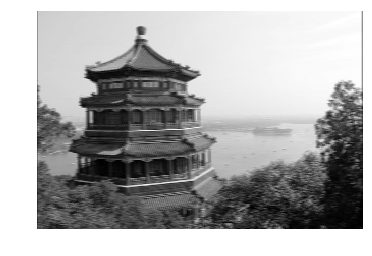

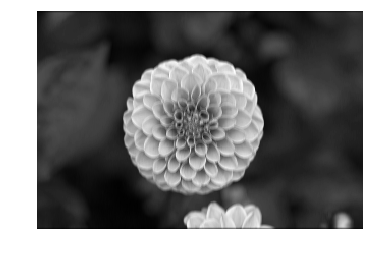

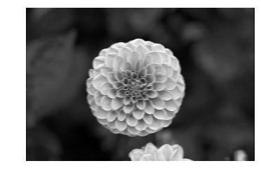

```python
for image_index in (0, 1):
    for feature_map_index in (0, 1):
        plot_image(output[image_index, :, :, feature_map_index])
        plt.show()
```

Using `tf.layers.conv2d()`:

- 텐서플로는 `tf.layers.conv2d()`함수를 사용하여 필터 변수(kernel)을 만들고 이를 무작위로 초기화한다.
- 2x2 stride와 SAME을 사용하여 2개의 7x7 feature map이 있는 컨볼루션 레이어 다음에 input placeholder를 만든다.

```python
reset_graph()

X = tf.placeholder(shape=(None, height, width, channels), dtype=tf.float32)
conv = tf.layers.conv2d(X, filters=2, kernel_size=7, strides=[2,2],
                        padding="SAME")
```

```python
init = tf.global_variables_initializer()

with tf.Session() as sess:
    init.run()
    output = sess.run(conv, feed_dict={X: dataset})
```

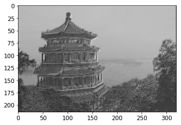

```python
plt.imshow(output[0, :, :, 1], cmap="gray") # plot 1st image's 2nd feature map
plt.show()
```

## VALID vs SAME padding

```python
reset_graph()

filter_primes = np.array([2., 3., 5., 7., 11., 13.], dtype=np.float32)
x = tf.constant(np.arange(1, 13+1, dtype=np.float32).reshape([1, 1, 13, 1]))
filters = tf.constant(filter_primes.reshape(1, 6, 1, 1))

valid_conv = tf.nn.conv2d(x, filters, strides=[1, 1, 5, 1], padding='VALID')
same_conv = tf.nn.conv2d(x, filters, strides=[1, 1, 5, 1], padding='SAME')

with tf.Session() as sess:
    print("VALID:\n", valid_conv.eval())
    print("SAME:\n", same_conv.eval())
```

```
VALID:
 [[[[ 184.]
   [ 389.]]]]
SAME:
 [[[[ 143.]
   [ 348.]
   [ 204.]]]]
```

```python
print("VALID:")
print(np.array([1,2,3,4,5,6]).T.dot(filter_primes))
print(np.array([6,7,8,9,10,11]).T.dot(filter_primes))
print("SAME:")
print(np.array([0,1,2,3,4,5]).T.dot(filter_primes))
print(np.array([5,6,7,8,9,10]).T.dot(filter_primes))
print(np.array([10,11,12,13,0,0]).T.dot(filter_primes))
```

```
VALID:
184.0
389.0
SAME:
143.0
348.0
204.0
```

### 2.4 Memory Requirements

- CNN의 문제점은 역전파의 역방향 패스가 순방향 패스동안 계산된 모든 intermediate 값을 필요로하기 때문에 학습중에 RAM양이 많이 필요하다.
- 학습 중 순방향 패스 중에 계산되는 모든 것이 역전파를 위해 보존되어야 하므로 필요한 ram의 양은 적어도 모든 레이어에서 필요한 총 ram 용량이다.
- 메모리 부족 오류로 학습 장애가 발생하면 mini-batch size를 줄여봐도 된다

### 3. Pooling layer

- 계산 부하, 메모리사용, 파라미터의 수를 줄이기 위해 입력이미지를 subsample 하는 것이다.
- convolutional layer와 마찬가지로 pooling layer의 각 뉴런은 receptive field내에 있는 이전 레이어의 제한된 수의 뉴런의 output에 연결된다.
- 단, pooling 뉴런에는 weight가 없다.
- 최댓값 또는 평균값으로 입력값에 대해 집계한다.
- pooling layer는 일반적으로 모든 input channel에 독립적으로 동작하기 때문에 output depth는 input depth와 동일하다.
- 텐서플로에서 max pooling layer를 구현하는 것은 매우 쉽다.

```python
batch_size, height, width, channels = dataset.shape

filters = np.zeros(shape=(7, 7, channels, 2), dtype=np.float32)
filters[:, 3, :, 0] = 1  # vertical line
filters[3, :, :, 1] = 1  # horizontal line
```

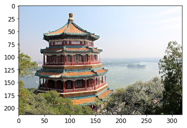

```python
X = tf.placeholder(tf.float32, shape=(None, height, width, channels))
max_pool = tf.nn.max_pool(X, ksize=[1,2,2,1], strides=[1,2,2,1],padding="VALID")

with tf.Session() as sess:
    output = sess.run(max_pool, feed_dict={X: dataset})

plt.imshow(output[0].astype(np.uint8))  # plot the output for the 1st image
plt.show()
```

- ksize argument는 입력 텐서의 4차원 모두를 따르는 커널 shape를 포함한다. [batch size, height, width, channels]
- 텐서플로는 여러 인스턴스에서 pooling을 지원하지 않아 ksize의 첫번째 요소는 1이어야한다.
- spatial dimensions(height& width)과 depth dimension에 대해 pooling을 지원하지 않기 때문에 ksize[1]과 ksize[2]는 둘다 1이어야 하거나 ksize[3]이 반드시 1이어야한다.

```
Saving figure china_original
```

[figure not shown]

```
Saving figure china_max_pool
```

[figure not shown]

```python
plot_color_image(dataset[0])
save_fig("china_original")
plt.show()

plot_color_image(output[0])
save_fig("china_max_pool")
plt.show()
```

## 4. CNN Architectures

- 일반적으로 CNN 구조는 몇개의 convolutional layers, pooling layer, 또 몇개의 convolutional layers(+ReLU), 그다음 pooling layer등을 쌓는다.
- 이미지는 계속 작아지지만 컨볼루션 레이어 덕분에 깊어진다. (feature map이 많아짐)
- 상위부분은 몇개의 fully connected layer(+ReLU)로 구성된 regular feedforward neural network가 추가되고 최종 레이어에는 예측을 출력한다.

LeNet-5I 아키텍쳐를 살펴본 후, LSVRC ImageNet Challenge 경기를 통해 수상작 AlexNet(2012), GoogleNet(2014), ResNet(2015)에 대해 살펴보자

### 4.1 LeNet-5

- 가장 널리 알려진 CNN 아키텍쳐
- 손으로 쓴 숫자인식인 **MNIST**에 널리 사용되었다.

[figure not shown]

- 28x28 픽셀이지만 32x32 픽셀로 zero padding 되고 네트워크에 공급(fed)되기 전에 정규화 된다.
- Average pooling layer 계산시 각 뉴런은 입력의 평균을 계산하고 결과를 학습 가능한 coefficient로 곱하고 학습할 수 있는 bias term을 추가한 다음 활성화함수에 적용한다.
- C3 map.에서 대부분의 뉴런은 3개 또는 4개의 S2 map의 뉴런과 연결된다.
- output layer는 input과 weight 벡터의 내적을 계산하는 대신 각 뉴런은 input 벡터와 weight벡터 사이의 Euclidian 거리의 제곱을 출력한다.

### 4.2 AlexNet (2012)

- 17%의 top-5 error rate를 달성했다.
- LeNet-5와 매우 유사하지만 더 크고 더 깊다.
- 각각의 컨볼루션 레이어 위에 pooling 레이어를 쌓는 대신 서로의 위에 직접 컨볼루션 레이어를 쌓았다.

[figure not shown]

- 특징은 두 가지의 정규화 기법을 사용했다는 점이다.
- 학습도중 F9과 F9의 레이어의 출력에 dropout(50%)를 적용했고, 다양한 offset으로 학습 이미지를 무작위로 shifting, flipping, lighting 조건을 번경하여 데이터를 확대했다.
- local response normalization이라 하는 C1과 C3의 ReLU 단계 직후 competitive normalization을 이용한다.
- 이러한 형태의 정규화는 동일한 위치에서 뉴런을 가장 강력하게 활성화시키는 뉴런을 만든다. 이렇게 하면 다양한 feature map을 특수화하고 더 광범위한 feature를 타색하여 궁극적으로 generalization을 향상시킬 수 있다.

### 4.3 GoogLeNet (2014)

- top-5 error를 7% 미만으로 낮춤
- GoogleNet은 AlexNet 보다 10배 적은 파라미터를 사용하며, inception modules라는 sub-network에 의해 파라미터를 효율적으로 사용할 수 있도록 하였다.

[figure not shown]

- "3x3+2(S)"는 3x3 커널과 stride 2, Same padding을 사용한다는 의미
- 모든 컨볼루션 레이어는 ReLU 활성화 함수를 사용한다.
- 또한 모든 레이어에서 stride1과 same padding이 사용되어 input의 height, width와 같도록 하였다.
- inception module이 1x1커널을 가지는 컨볼루션 레이어를 가지는것은 두가지 용도로 사용된다.
- 1. 입력보다 훨씬 적은 수의 feature map을 출력하도록 구성되므로 병목현상이 발생하여 차원수가 저하된다.
- 1. 컨볼루션 레이어 [1x1, 3x3]과 [1x1, 5x5]의 각 쌍은 보다 복잡한 패턴을 캡처할 수 있는 단일의 강력한 컨볼루션 레이어와 같은 역할을 한다.
- 즉 전체 inception module을 steroids의 컨볼루션 레이어로 생각할 수 있고 다양한 scale로 복잡한 패턴을 캡쳐하는 feature map을 출력할 수 있다.

[figure not shown]

- googlenet cnn의 아키텍쳐는 매우 깊고 3개의 레이어가 포함된 9개의 inception module을 포함한다.
- kernel size앞에 표시된 숫자는 각 레이어에서 출력된 feature map의 개수이다.
- GoogleNet 네트워크
- 처음 두 레이어는 이미지의 높이와 너비를 4로 나눈다. -> computational load가 줄어든다
- local response normalization layer는 이전 계층이 다양한 feature를 학습하도록 한다.
- 두개의 컨볼루션 레이어가 이어지며 첫번째 레이어는 bottleneck layer처럼 진행된다.
- local response normalization layer는 이전 레이어가 다양한 패턴을 캡쳐하도록 한다.
- 다음으로 max pooling 레이어는 이미지 높이와 너비를 2씩 줄여 다시 계산 속도를 높인다.
- 9개의 inception modules로 이루어진 스택을 지나 max pooling 레이어가 삽입되어 차원을 줄이고 속도를 높인다.
- average pooling 레이어는 valid padding을 가진 feature map 크기의 커널을 사용하여 1x1 feature map을 출력한다. : Global average pooling이라 함, 이전 계층이 각 대상 클래스에 대한 실제 confidence한 maps인 feature map을 생성하도록 한다. 따라서 CNN 상단에 여러개의 fully connected layer가 있을 필요가 없어 파라미터의 수가 줄고 over-fitting의 위험이 감소한다.
- 마지막 레이어는 정규화를 위한 dropout, softmax activation 함수를 가진 fully connected 레이어로 estimated 클래스의 확률을 출력한다.

## MNIST

```python
height = 28
width = 28
channels = 1
n_inputs = height * width

conv1_fmaps = 32
conv1_ksize = 3
conv1_stride = 1
conv1_pad = "SAME"

conv2_fmaps = 64
conv2_ksize = 3
conv2_stride = 2
conv2_pad = "SAME"

pool3_fmaps = conv2_fmaps

n_fc1 = 64
n_outputs = 10

reset_graph()

with tf.name_scope("inputs"):
    X = tf.placeholder(tf.float32, shape=[None, n_inputs], name="X")
    X_reshaped = tf.reshape(X, shape=[-1, height, width, channels])
    y = tf.placeholder(tf.int32, shape=[None], name="y")

conv1 = tf.layers.conv2d(X_reshaped, filters=conv1_fmaps, kernel_size=conv1_ksize,
                         strides=conv1_stride, padding=conv1_pad,
                         activation=tf.nn.relu, name="conv1")
conv2 = tf.layers.conv2d(conv1, filters=conv2_fmaps, kernel_size=conv2_ksize,
                         strides=conv2_stride, padding=conv2_pad,
                         activation=tf.nn.relu, name="conv2")

with tf.name_scope("pool3"):
    pool3 = tf.nn.max_pool(conv2, ksize=[1, 2, 2, 1], strides=[1, 2, 2, 1], padding="VALID")
    pool3_flat = tf.reshape(pool3, shape=[-1, pool3_fmaps * 7 * 7])

with tf.name_scope("fc1"):
    fc1 = tf.layers.dense(pool3_flat, n_fc1, activation=tf.nn.relu, name="fc1")

with tf.name_scope("output"):
    logits = tf.layers.dense(fc1, n_outputs, name="output")
    Y_proba = tf.nn.softmax(logits, name="Y_proba")

with tf.name_scope("train"):
    xentropy = tf.nn.sparse_softmax_cross_entropy_with_logits(logits=logits, labels=y)
    loss = tf.reduce_mean(xentropy)
    optimizer = tf.train.AdamOptimizer()
    training_op = optimizer.minimize(loss)

with tf.name_scope("eval"):
    correct = tf.nn.in_top_k(logits, y, 1)
    accuracy = tf.reduce_mean(tf.cast(correct, tf.float32))

with tf.name_scope("init_and_save"):
    init = tf.global_variables_initializer()
    saver = tf.train.Saver()
```

Note: if you are using Python 3.6 on OSX, you need to run the following command on terminal to install the certifi package of certificates because Python 3.6 on OSX has no certificates to validate SSL connections (see this [StackOverflow question](https://stackoverflow.com/questions/27835619/urllib-and-ssl-certificate-verify-failed-error)):

```
$ /Applications/Python\ 3.6/Install\ Certificates.command
```

```python
from tensorflow.examples.tutorials.mnist import input_data
mnist = input_data.read_data_sets("/tmp/data/")
```

```
Extracting /tmp/data/train-images-idx3-ubyte.gz
Extracting /tmp/data/train-labels-idx1-ubyte.gz
Extracting /tmp/data/t10k-images-idx3-ubyte.gz
Extracting /tmp/data/t10k-labels-idx1-ubyte.gz
```

```python
n_epochs = 10
batch_size = 100

with tf.Session() as sess:
    init.run()
    for epoch in range(n_epochs):
        for iteration in range(mnist.train.num_examples // batch_size):
            X_batch, y_batch = mnist.train.next_batch(batch_size)
            sess.run(training_op, feed_dict={X: X_batch, y: y_batch})
        acc_train = accuracy.eval(feed_dict={X: X_batch, y: y_batch})
        acc_test = accuracy.eval(feed_dict={X: mnist.test.images, y: mnist.test.labels})
        print(epoch, "Train accuracy:", acc_train, "Test accuracy:", acc_test)

        save_path = saver.save(sess, "./my_mnist_model")
```

```
0 Train accuracy: 0.99 Test accuracy: 0.9765
1 Train accuracy: 0.99 Test accuracy: 0.9809
2 Train accuracy: 0.97 Test accuracy: 0.9837
3 Train accuracy: 1.0 Test accuracy: 0.9871
4 Train accuracy: 1.0 Test accuracy: 0.9882
5 Train accuracy: 0.97 Test accuracy: 0.9881
6 Train accuracy: 1.0 Test accuracy: 0.9891
7 Train accuracy: 0.99 Test accuracy: 0.9887
8 Train accuracy: 1.0 Test accuracy: 0.988
9 Train accuracy: 1.0 Test accuracy: 0.9898
```